# F3.1: i primi metodi di analisi si comportano sui dati simulati come sui dati veri?

geo_spatialtrans, report di step (protocollo v2)

Published

November 18, 2026

### In breve: i metodi di analisi si comportano sui dati simulati come sui dati veri, e che cosa va sistemato per primo nel simulatore?

**A cosa serviva.** Il simulatore deve servire a mettere alla prova i metodi di analisi: un metodo dovrebbe comportarsi sui dati simulati come su quelli veri. Abbiamo fatto girare i due metodi più usati su Visium HD, bin2cell (ricostruisce le cellule allargando i nuclei) e RCTD (dice quali tipi cellulari ci sono in ogni quadrato di 8 µm), sulle stesse 30 aree dei sei tessuti, simulate e vere. Il margine accettabile era quanto ogni misura varia fra le aree vere dello stesso tessuto. Dopo la tua prima lettura abbiamo indagato, qui dentro, i quattro punti rimasti aperti.

**Cosa abbiamo trovato.**

1. **Su metà dei confronti, 18 su 36, i metodi si comportano sul simulato in modo diverso che sul vero, soprattutto nell’intestino di topo, nel tumore del colon, nello stroma del tumore e nel linfonodo.**
   - Le cellule ricostruite da bin2cell sono più «sporche»: nel tumore il 15 % dei trascritti dei geni marcatori viene da altri tipi cellulari, contro meno del 5 % nel vero.
   - RCTD trova più miscugli di due tipi (nel tumore quasi un quadrato su cinque, contro uno su venti) e tipi meno ordinati nello spazio (nello stroma due quadrati vicini hanno lo stesso tipo nel 65 % dei casi, contro l’89 %).
   - Il numero di trascritti per cellula invece torna in tutti e sei i tessuti.
2. **La causa principale resta la disposizione: il simulatore mette i tipi cellulari a caso uno accanto all’altro, mentre nei tessuti veri si raggruppano.**
   - Nell’intestino simulato quasi la metà dei vicini di una cellula è di un altro tipo, nel vero un quinto; nel tumore un terzo contro uno su sedici.
   - La semina a compartimenti, che il simulatore ha già, mescola i vicini come nel vero e avvicina i metodi al vero in quattro tessuti: 5 delle 17 differenze spariscono.
3. **Le indagini hanno trovato una seconda causa: il simulatore fa finire nei nuclei troppi trascritti delle cellule vicine.**
   - Nel linfonodo i geni degli anticorpi, tipici di linfociti B e plasmacellule, nei nuclei dei linfociti T simulati sono quasi cinque volte più che nei veri. Nel simulato un quinto di quello che si raccoglie sopra un nucleo T viene da linfociti B o plasmacellule; nel vero al massimo un ventesimo.
   - È questo, e non i profili dei linfociti B (che sono giusti), a far chiamare a RCTD plasmacellule il 30 % dei quadrati simulati contro il 13 % dei veri: tre quarti dell’eccesso viene da quadrati di altre cellule.
   - Lo stesso succede nell’intestino, nel tumore e nello stroma: i nuclei veri sono puliti quanto i profili di partenza, quelli simulati no. Anche con i profili presi dal solo nucleo l’eccesso resta, quindi nasce dove il simulatore mette e sposta i trascritti.
   - La semina a compartimenti ne toglie circa metà nell’intestino e nel tumore, meno nello stroma e nel linfonodo. Nell’intestino e nel linfonodo i vicini sono già mescolati come nel vero e l’eccesso resta: è una causa distinta dalla disposizione.
   - Il sospetto, da verificare, cade su quanto lontano il simulatore sposta i trascritti. Quei valori furono tarati su quantità che non distinguono il tipo di cellula; i geni marcatori, usati qui, sono la prima misura che lo vede.
4. **Il cuore: una misura giusta esiste già.** Le misure dei metodi non vedevano che le cellule vere del cuore sono allungate e quelle simulate no. Una misura dell’orientamento dei trascritti, la stessa usata nei controlli dei conteggi, lo vede chiaramente nel cuore e non trova differenze negli altri cinque tessuti: è quella da usare come controllo negativo.
5. **Le aree simulate si somigliano troppo, e sappiamo perché.** Fra le cinque aree simulate la composizione dei tipi varia da 30 a migliaia di volte meno che fra le vere, la densità delle cellule da 5 a 150 volte meno, perché il simulatore usa una sola composizione e una sola densità per tessuto. Nel linfonodo, per esempio, follicoli e paracorteccia simulati hanno la stessa quota di linfociti B (49 %), mentre nei veri va dal 33 % al 64 %. Le misure dei metodi variano di meno negli stessi tessuti.
6. **L’errore di geometria del cervello è capito e ha una correzione provata.** Un buco di una zona toccava il suo bordo in un solo punto, un caso che la funzione di triangolazione non sa trattare. Un restringimento di un milionesimo di micron, usato solo quando tutto il resto fallisce, lo risolve; un’altra area di controllo esce identica con e senza correzione.
7. **Nel cervello l’eccesso di trascritti estranei sta nei profili, non nello spostamento,** e la composizione dei tipi chiamati da RCTD (troppi neuroni) resta da guardare.

**Cosa devi decidere.**

1. **La prova della semina a compartimenti (lo step che hai già chiesto) deve misurare anche quanto sono sporchi i nuclei, per tenere separate le due cause? Consiglio di sì.**
   - Costa poco: le misure sono pronte e girano in pochi minuti sulle stesse simulazioni.
   - Lo step correggerebbe anche l’errore di geometria con la correzione provata qui.
   - Alternativa: rivedere nello stesso step anche quanto lontano si spostano i trascritti. Sconsiglio: due cambiamenti insieme non permettono di capire quale ha fatto cosa.
   - Alternativa: fare prima lo step sullo spostamento dei trascritti e poi la prova dei compartimenti. Sconsiglio: la disposizione resta la causa più grande, e lo spostamento va prima misurato bene tipo per tipo.

**Comunque**

- Lo spostamento dei trascritti verso i nuclei vicini diventa una voce a sé in coda, con la misura per verificarlo già scritta.
- La variabilità fra aree (una sola composizione per tessuto) e la composizione del cervello restano in coda: ora sappiamo da dove vengono, ma decidere come farle variare è una scelta a parte.
- Per il cuore useremo la misura dell’orientamento nelle prossime prove dei metodi.

Appena approvi, lo step è chiuso.

**Sui tempi di calcolo.** Li ho misurati io sul server. La prima parte dello step: le 30 aree vere con i due metodi circa un’ora e mezza; le 85 simulazioni con i due metodi circa 4 ore con 6 processi; le 30 aree con i compartimenti circa 3 ore con 5 processi. Le indagini di oggi hanno riusato quei risultati: la prova della geometria (tre simulazioni del cervello) circa 18 minuti, le altre letture da 1 a 2 minuti ciascuna; la durata della prima tornata, su linfonodo, cuore e variabilità, non l’ho registrata. La prova dei compartimenti con due semi costerebbe circa 4 ore con 6 processi.

# Dubbi rinviati

| cosa | perché | cosa serve per chiuderlo | step destinatario | voce di BACKLOG |
| --- | --- | --- | --- | --- |
| triangolazione fallita nel cervello r3 con la semina a compartimenti | difetto del codice dello Step 2; diagnosticato in PH-7: un buco tocca il bordo esterno in un punto | portare nel pacchetto l’ultimo ripiego provato (erosione di 1e-6 µm dopo la semplificazione) con una prova sulla geometria salvata `PH7_geometry.wkt` | step della prova della semina a compartimenti | BL-259 |
| linfonodo: plasmacellule in eccesso con RCTD | spiegato in PH-4 (dopo): segnale di B e plasmacellule nei nuclei e nei blocchi di altre cellule; i profili sono giusti | rifare la misura dopo i compartimenti; il resto passa a BL-265 | step della prova della semina a compartimenti | BL-260 |
| cervello: RCTD chiama neuroni il 75 % dei quadrati simulati contro il 55 % dei veri; coerenza spaziale in eccesso | non dipende dalla mescolanza né dai profili | confrontare la composizione del preset del cervello con i tipi chiamati sul vero, area per area | da assegnare (con la densità dei preset) | BL-261 |
| le aree simulate di un tessuto variano fra loro molto meno delle vere | spiegato in PH-6: una sola composizione e densità per tessuto nel preset | decidere se e come far variare composizione e densità fra aree (per esempio follicoli e paracorteccia nel linfonodo) | da assegnare | BL-262 |
| il controllo negativo del cuore | PH-5: l’anisotropia del campo degli UMI vede il cuore (0.097 ± 0.015 vero meno simulato), il campo dei tipi no | usarla nelle prossime prove dei metodi | prossimo step che rifà le misure dei metodi | BL-263 |
| definizioni delle misure per cellula (quadratini fuori dal tessuto; marcatori comuni a due tipi nel linfonodo) | segnalate dalla revisione; non spostano esiti | precisarle prima di riusare le misure | prossimo step che rifà le misure dei metodi | BL-264 |
| troppi trascritti delle cellule vicine nei nuclei (intestino, tumore, stroma, linfonodo) | trovato in PH-4 e nel seguito; distinto dalla disposizione | misurare tipo per tipo quanto si spostano i trascritti nel vero (marcatori e geni delle immunoglobuline nei nuclei) e rivedere i parametri dello spostamento | step dedicato dopo la prova dei compartimenti | BL-265 |

# Cancelli, previsioni, controprove

Pre-registrazione: cancelli `fc79131`, previsioni e intervalli `c82580c`; ok di Luca sulle previsioni del 2026-11-12, `ba1ee86`.

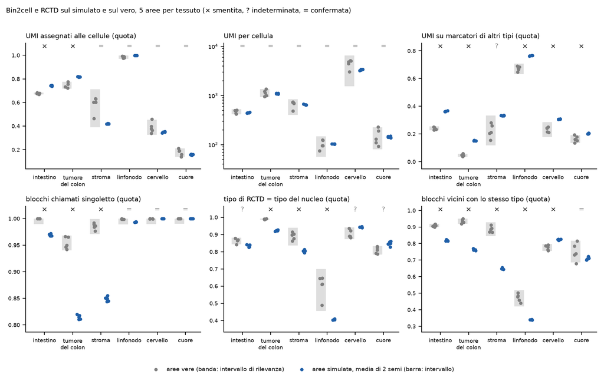

Tabelle: `results/F3.1/F3.1_verdicts.csv` (una riga per giudizio), `F3.1_CP1.csv`, `F3.1_CP2.csv`, `F3.1_CP3.csv`, `F3.1_R1.csv`, `F3.1_R1_summary.csv`, `F3.1_truth.csv`; per area e per esecuzione `F3.1_real_runs.csv`, `F3.1_sim_runs.csv`, `F3.1_sim_areas.csv`, `F3.1_simnuc_runs.csv`. Figure in `reports/F3.1_parts/`.

### Cancelli

[output not shown]

### Previsioni

Conteggio per misura (36 giudizi: 14 confermati, 4 indeterminati, 18 smentiti):

| misura | confermata | indeterminata | smentita |
| --- | --- | --- | --- |
| M-1 | 4 | 0 | 2 |
| M-2 | 6 | 0 | 0 |
| M-3 | 0 | 1 | 5 |
| M-4 | 3 | 0 | 3 |
| M-5 | 0 | 3 | 3 |
| M-6 | 1 | 0 | 5 |

| misura | tessuto | vero | intervallo di rilevanza | simulato | intervallo del simulato | esito |
| --- | --- | --- | --- | --- | --- | --- |
| M-1 | intestino | 0.676 | 0.667-0.684 | 0.743 | 0.738-0.747 | smentita per eccesso |
| M-2 | intestino | 470 | 414-526 | 446 | 440-453 | confermata |
| M-3 | intestino | 0.241 | 0.226-0.255 | 0.363 | 0.360-0.367 | smentita per eccesso |
| M-4 | intestino | 1.000 | 0.990-1.000 | 0.969 | 0.966-0.972 | smentita per difetto |
| M-5 | intestino | 0.864 | 0.842-0.882 | 0.835 | 0.825-0.843 | indeterminata |
| M-6 | intestino | 0.909 | 0.898-0.918 | 0.819 | 0.814-0.824 | smentita per difetto |
| M-1 | tumore del colon | 0.744 | 0.717-0.776 | 0.817 | 0.815-0.820 | smentita per eccesso |
| M-2 | tumore del colon | 1136 | 923-1352 | 1096 | 1071-1117 | confermata |
| M-3 | tumore del colon | 0.045 | 0.035-0.057 | 0.152 | 0.149-0.154 | smentita per eccesso |
| M-4 | tumore del colon | 0.954 | 0.940-0.968 | 0.815 | 0.809-0.820 | smentita per difetto |
| M-5 | tumore del colon | 0.990 | 0.987-0.993 | 0.923 | 0.918-0.927 | smentita per difetto |
| M-6 | tumore del colon | 0.936 | 0.920-0.951 | 0.763 | 0.757-0.769 | smentita per difetto |
| M-1 | stroma | 0.586 | 0.389-0.713 | 0.419 | 0.416-0.423 | confermata |
| M-2 | stroma | 669 | 403-837 | 653 | 642-668 | confermata |
| M-3 | stroma | 0.222 | 0.118-0.334 | 0.333 | 0.330-0.335 | indeterminata |
| M-4 | stroma | 0.985 | 0.971-0.999 | 0.849 | 0.843-0.854 | smentita per difetto |
| M-5 | stroma | 0.890 | 0.835-0.940 | 0.804 | 0.795-0.812 | smentita per difetto |
| M-6 | stroma | 0.886 | 0.845-0.929 | 0.649 | 0.644-0.654 | smentita per difetto |
| M-1 | linfonodo | 0.984 | 0.969-0.999 | 0.998 | 0.998-0.998 | confermata |
| M-2 | linfonodo | 102 | 56-149 | 103 | 102-103 | confermata |
| M-3 | linfonodo | 0.672 | 0.630-0.708 | 0.765 | 0.763-0.767 | smentita per eccesso |
| M-4 | linfonodo | 0.999 | 0.989-1.000 | 0.993 | 0.993-0.994 | confermata |
| M-5 | linfonodo | 0.600 | 0.456-0.700 | 0.406 | 0.403-0.409 | smentita per difetto |
| M-6 | linfonodo | 0.472 | 0.421-0.518 | 0.340 | 0.338-0.341 | smentita per difetto |
| M-1 | cervello | 0.387 | 0.326-0.453 | 0.349 | 0.343-0.354 | confermata |
| M-2 | cervello | 4514 | 1534-6564 | 3344 | 3239-3435 | confermata |
| M-3 | cervello | 0.232 | 0.179-0.285 | 0.307 | 0.305-0.309 | smentita per eccesso |
| M-4 | cervello | 1.000 | 0.990-1.000 | 1.000 | 1.000-1.000 | confermata |
| M-5 | cervello | 0.904 | 0.873-0.941 | 0.943 | 0.939-0.947 | indeterminata |
| M-6 | cervello | 0.775 | 0.754-0.796 | 0.824 | 0.820-0.827 | smentita per eccesso |
| M-1 | cuore | 0.177 | 0.139-0.211 | 0.158 | 0.152-0.163 | confermata |
| M-2 | cuore | 150 | 80-226 | 143 | 137-151 | confermata |
| M-3 | cuore | 0.164 | 0.136-0.192 | 0.203 | 0.199-0.207 | smentita per eccesso |
| M-4 | cuore | 1.000 | 0.990-1.000 | 1.000 | 1.000-1.000 | confermata |
| M-5 | cuore | 0.809 | 0.783-0.832 | 0.847 | 0.830-0.862 | indeterminata |
| M-6 | cuore | 0.750 | 0.685-0.816 | 0.708 | 0.698-0.721 | confermata |

Contro le previsioni scritte: P-2 e P-4 come previsto in tutti i tessuti; P-1 smentita anche nel tumore del colon (oltre l’intestino); P-3 smentita anche nel cervello e nel cuore; P-5 indeterminata nell’intestino (prevista smentita); P-6 smentita per eccesso nel cervello (prevista indeterminata) e confermata nel cuore (prevista indeterminata). Gli scarti delle smentite vanno da 1.4 a 25 semi-ampiezze dell’intervallo del vero (`gap_in_halfwidths`).

Osservazione non prevista (descrittiva): le 5 aree simulate di un tessuto variano fra loro molto meno delle 5 aree vere (figura 1: punti blu quasi sovrapposti); per questo l’intervallo del simulato è stretto, e una conferma vuol dire «il simulato cade nella variabilità del vero», non che ne riproduca la variabilità.

### Controprove

- **CP-1 (le misure vedono gli errori di assegnazione): passata** in tutti i tessuti e su entrambi i lati per M-3 e M-5 (intestino M-3 real 0.179 ± 0.004; intestino M-5 real 0.341 ± 0.005; tumore del colon M-3 real 0.150 ± 0.018; tumore del colon M-5 real 0.175 ± 0.018; stroma M-3 real 0.135 ± 0.009; stroma M-5 real 0.197 ± 0.014; linfonodo M-3 real 0.057 ± 0.006; linfonodo M-5 real 0.187 ± 0.007; cervello M-3 real 0.224 ± 0.013; cervello M-5 real 0.336 ± 0.010; cuore M-3 real 0.094 ± 0.030; cuore M-5 real 0.093 ± 0.036; intestino M-3 sim 0.143 ± 0.002; tumore del colon M-3 sim 0.236 ± 0.001; stroma M-3 sim 0.375 ± 0.003; linfonodo M-3 sim 0.072 ± 0.001; cervello M-3 sim 0.154 ± 0.003; cuore M-3 sim 0.161 ± 0.007; intestino M-5 sim 0.130 ± 0.002; tumore del colon M-5 sim 0.233 ± 0.002; stroma M-5 sim 0.509 ± 0.005; linfonodo M-5 sim 0.109 ± 0.002; cervello M-5 sim 0.276 ± 0.003; cuore M-5 sim 0.245 ± 0.010).
- **CP-2 (le misure senza verità seguono la verità): passata, debolmente.** Correlazione di Spearman sulle 10 esecuzioni simulate per tessuto, positiva per M-3 in 4 tessuti su 6 e per M-5 in 5 su 6 (criterio: almeno 4). Con 10 punti per tessuto le correlazioni sono rumorose; in cervello e cuore M-3 non segue la verità.

| tessuto | M-3 contro verità (Spearman) | M-5 contro verità (Spearman) |
| --- | --- | --- |
| intestino | 0.85 | -0.12 |
| tumore del colon | 0.85 | 0.71 |
| stroma | 0.16 | 0.71 |
| linfonodo | 0.85 | 0.21 |
| cervello | -0.26 | 0.36 |
| cuore | -0.08 | 0.02 |

- **CP-3 (contaminazione contata due volte): fallita, quindi l’ipotesi di E-3 è smentita.** Con i profili dal solo nucleo la quota di marcatori estranei del simulato si avvicina al vero di almeno metà dello scarto solo nel cervello (1 tessuto su 4, criterio 3 su 4). Anche i profili veri generati dal solo nucleo hanno quasi la stessa quota di marcatori estranei di quelli con la corona (`F3.1_truth.csv`, colonna `foreign_profile`: intestino 0.221 contro 0.224, tumore 0.037 contro 0.044, linfonodo 0.634 contro 0.645). L’UMI per quadratino resta invariato (intestino 29.15 contro 29.14; tumore del colon 47.41 contro 47.41; linfonodo 11.56 contro 11.56; cervello 44.32 contro 44.32; cuore 3.60 contro 3.60).

| tessuto | misura | vero | simulato (k = 0) | profili dal solo nucleo | frazione dello scarto chiusa |
| --- | --- | --- | --- | --- | --- |
| intestino | M-3 | 0.241 | 0.361 | 0.369 | -0.06 |
| intestino | M-5 | 0.864 | 0.836 | 0.839 | 0.13 |
| intestino | M-6 | 0.909 | 0.819 | 0.819 | 0.00 |
| tumore del colon | M-3 | 0.045 | 0.152 | 0.140 | 0.11 |
| tumore del colon | M-5 | 0.990 | 0.922 | 0.921 | -0.01 |
| tumore del colon | M-6 | 0.936 | 0.762 | 0.764 | 0.01 |
| linfonodo | M-3 | 0.672 | 0.765 | 0.757 | 0.08 |
| linfonodo | M-5 | 0.600 | 0.405 | 0.415 | 0.05 |
| linfonodo | M-6 | 0.472 | 0.339 | 0.339 | 0.00 |
| cervello | M-3 | 0.232 | 0.306 | 0.259 | 0.65 |
| cervello | M-5 | 0.904 | 0.942 | 0.938 | 0.09 |
| cervello | M-6 | 0.775 | 0.823 | 0.849 | -0.53 |
| cuore | M-3 | 0.164 | 0.199 | 0.181 | 0.50 |
| cuore | M-5 | 0.809 | 0.844 | 0.825 | 0.54 |
| cuore | M-6 | 0.750 | 0.708 | 0.698 | -0.24 |

- **CP-4 (il cuore come controllo negativo): fallita.** La coerenza spaziale (M-6) del cuore simulato è confermata (0.708 contro 0.685-0.816): la misura non vede le cellule allungate del cuore vero. Era stato messo in conto dopo la fase A (attesa indeterminata). Vuol dire che M-6 non serve a giudicare l’anisotropia; non tocca le altre conclusioni.

### Regola R-1

Giudizi smentiti fuori dal cuore: 17. Attribuzione (`F3.1_R1.csv`): disposizione dei tipi 7, non attribuiti 7, densità dei preset 2, profili 1. **Limite da sistemare per primo per la regola: la disposizione dei tipi** (7 giudizi, scarto medio 7.7 semi-ampiezze). Registrato come decisione tecnica in F3.1: il limite del simulatore da sistemare per primo è la disposizione dei tipi cellulari (DEC-087).

| misura | tessuto | scarto | limite attribuito |
| --- | --- | --- | --- |
| M-1 | intestino | +0.067 | densità dei preset |
| M-3 | intestino | +0.122 | non attribuito |
| M-4 | intestino | -0.031 | disposizione dei tipi |
| M-6 | intestino | -0.090 | disposizione dei tipi |
| M-1 | tumore del colon | +0.074 | densità dei preset |
| M-3 | tumore del colon | +0.106 | non attribuito |
| M-4 | tumore del colon | -0.139 | disposizione dei tipi |
| M-5 | tumore del colon | -0.068 | non attribuito |
| M-6 | tumore del colon | -0.173 | disposizione dei tipi |
| M-4 | stroma | -0.137 | disposizione dei tipi |
| M-5 | stroma | -0.086 | non attribuito |
| M-6 | stroma | -0.237 | disposizione dei tipi |
| M-3 | linfonodo | +0.093 | non attribuito |
| M-5 | linfonodo | -0.195 | non attribuito |
| M-6 | linfonodo | -0.133 | disposizione dei tipi |
| M-3 | cervello | +0.074 | profili dai nuclei con la corona |
| M-6 | cervello | +0.049 | non attribuito |

### Verità del simulato (descrittiva)

| tessuto | purezza delle cellule di bin2cell | recupero | quota da cellule di altro tipo | accuratezza del primo tipo di RCTD |
| --- | --- | --- | --- | --- |
| intestino | 0.54 | 0.38 | 0.19 | 0.89 |
| tumore del colon | 0.74 | 0.60 | 0.08 | 0.95 |
| stroma | 0.85 | 0.36 | 0.10 | 0.81 |
| linfonodo | 0.59 | 0.59 | 0.23 | 0.45 |
| cervello | 0.86 | 0.29 | 0.04 | 0.86 |
| cuore | 0.85 | 0.13 | 0.06 | 0.81 |

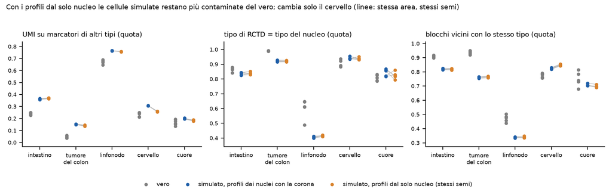

Controprova della contaminazione contata due volte: vero, simulato con i profili dai nuclei con la corona, simulato con i profili dal solo nucleo (stessi semi). **Cosa guardare**: le coppie blu-arancio quasi orizzontali: i profili non sono la causa.

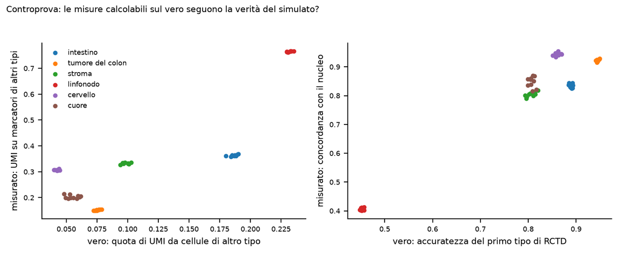

Misure calcolabili sul vero contro la verità del simulato, 10 esecuzioni per tessuto.

# Analisi a posteriori

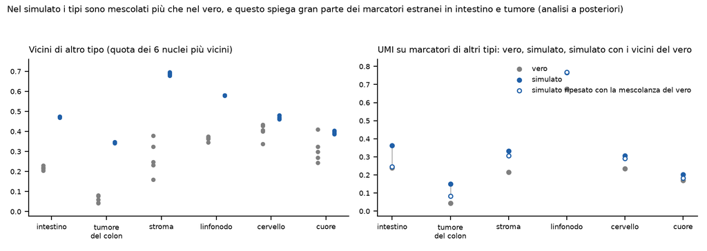

Mescolanza dei tipi fra vicini e marcatori estranei ripesati con la mescolanza del vero. **Cosa guardare**: in intestino e tumore il cerchio vuoto (simulato ripesato) scende quasi al grigio.

**PH-1, mescolanza dei tipi fra vicini** (`tools/F3.1_PH1_mixing.py`, `results/F3.1/F3.1_PH1_mixing*.csv`; figura 4). Per ogni nucleo con tipo, quota dei 6 nuclei con tipo più vicini che sono di un altro tipo; stessa definizione sui due lati. Nel simulato è più alta in tutti i tessuti; dentro ogni lato i marcatori estranei crescono con la mescolanza (tranne il linfonodo, dove i marcatori non separano i linfociti B dai T). Ripesando le cellule simulate per livello di mescolanza con la distribuzione del vero, si spiega gran parte dello scarto di M-3 in intestino e tumore:

| tessuto | vicini di altro tipo, vero | simulato | M-3 vero | M-3 simulato | M-3 simulato ripesato | scarto spiegato |
| --- | --- | --- | --- | --- | --- | --- |
| intestino | 0.22 | 0.47 | 0.240 | 0.363 | 0.247 | 95% |
| tumore del colon | 0.06 | 0.35 | 0.045 | 0.151 | 0.082 | 65% |
| stroma | 0.27 | 0.69 | 0.216 | 0.332 | 0.307 | 22% |
| linfonodo | 0.36 | 0.58 | 0.674 | 0.765 | 0.768 | -3% |
| cervello | 0.40 | 0.47 | 0.236 | 0.307 | 0.291 | 22% |
| cuore | 0.31 | 0.40 | 0.169 | 0.203 | 0.183 | 59% |

**PH-2, composizione dei primi tipi di RCTD** (`F3.1_PH1_mixing_rctd_composition.csv`). Nel simulato RCTD chiama il tipo dominante più spesso del vero: intestino epitelio 0.87 contro 0.67 e stroma (lamina propria e muscolo) 0.08 contro 0.25, benché nel simulato le cellule stromali siano il 21 % come fra i nuclei veri; stroma del tumore fibroblasti 0.23 contro 0.60; cervello neuroni 0.75 contro 0.55; linfonodo plasmacellule 0.30 contro 0.13 e linfociti T 0.21 contro 0.42.

**PH-3, semina a compartimenti** (livelli Q6 di S1.6, 30 aree × 1 seme, stessi semi di k = 0; `tools/F3.1_run_PH3.sh`, `tools/F3.1_PH3_analysis.py`): la semina a compartimenti riporta la mescolanza dei vicini al livello del vero (quota dei vicini di altro tipo, semina uniforme → compartimenti: intestino 0.47 → 0.23 (vero 0.22); tumore del colon 0.35 → 0.10 (vero 0.06); stroma 0.69 → 0.31 (vero 0.27); linfonodo 0.58 → 0.37 (vero 0.36); cervello 0.47 → 0.36 (vero 0.40); cuore 0.40 → 0.32 (vero 0.31)). Le misure dei metodi si avvicinano al vero in intestino, tumore, stroma e linfonodo: fra i giudizi smentiti con la semina uniforme, lo scarto si chiude dal 37 al 95 % per singoletti, concordanza e coerenza spaziale (nell’intestino la concordanza passa oltre il vero), e di circa la metà per i marcatori estranei nell’intestino e nel tumore (0.52, 0.59; nello stroma, non smentito, 0.48), molto meno nel linfonodo (0.17); 5 dei 17 giudizi smentiti fuori dal cuore non lo sono più (posizione descrittiva, un seme). Restano: UMI assegnati in eccesso in intestino e tumore (densità: con i compartimenti peggiorano appena), marcatori estranei nell’intestino (0.298 contro 0.241) e nel linfonodo, il cervello (mescolanza già vicina al vero; nessuna misura si muove), e la concordanza dell’intestino che supera il vero (0.907 contro 0.843-0.882). UMI per quadratino e cellule per area invariati. **Anomalia**: nell’area r3 del cervello la simulazione a pezzi sul livello a compartimenti si ferma («.s27_cdt(): triangolazione fallita anche dopo la semplificazione (geometria 168)»): il cervello ha 4 aree su 5 in PH-3 (voce di BACKLOG).

| misura | tessuto | vero | semina uniforme | compartimenti | frazione dello scarto chiusa | esito con la semina uniforme | posizione dei compartimenti rispetto al vero (descrittiva) |
| --- | --- | --- | --- | --- | --- | --- | --- |
| M-1 | intestino | 0.676 | 0.743 | 0.756 | -0.19 | smentita | smentita |
| M-2 | intestino | 470 | 447 | 453 | 0.26 | confermata | confermata |
| M-3 | intestino | 0.241 | 0.361 | 0.298 | 0.52 | smentita | smentita |
| M-4 | intestino | 1.000 | 0.968 | 0.980 | 0.37 | smentita | smentita |
| M-5 | intestino | 0.864 | 0.836 | 0.907 | 2.50 | indeterminata | smentita |
| M-6 | intestino | 0.909 | 0.819 | 0.854 | 0.40 | smentita | smentita |
| M-1 | tumore del colon | 0.744 | 0.817 | 0.827 | -0.14 | smentita | smentita |
| M-2 | tumore del colon | 1136 | 1094 | 1101 | 0.18 | confermata | confermata |
| M-3 | tumore del colon | 0.045 | 0.152 | 0.088 | 0.59 | smentita | smentita |
| M-4 | tumore del colon | 0.954 | 0.815 | 0.947 | 0.95 | smentita | indeterminata |
| M-5 | tumore del colon | 0.990 | 0.922 | 0.977 | 0.82 | smentita | smentita |
| M-6 | tumore del colon | 0.936 | 0.762 | 0.917 | 0.89 | smentita | indeterminata |
| M-1 | stroma | 0.586 | 0.421 | 0.495 | 0.45 | confermata | confermata |
| M-2 | stroma | 669 | 657 | 763 | 8.47 | confermata | confermata |
| M-3 | stroma | 0.222 | 0.334 | 0.281 | 0.48 | indeterminata | confermata |
| M-4 | stroma | 0.985 | 0.848 | 0.934 | 0.62 | smentita | smentita |
| M-5 | stroma | 0.890 | 0.802 | 0.873 | 0.80 | smentita | confermata |
| M-6 | stroma | 0.886 | 0.647 | 0.791 | 0.60 | smentita | smentita |
| M-1 | linfonodo | 0.984 | 0.998 | 0.990 | 0.62 | confermata | confermata |
| M-2 | linfonodo | 102 | 103 | 102 | 1.15 | confermata | confermata |
| M-3 | linfonodo | 0.672 | 0.765 | 0.749 | 0.17 | smentita | smentita |
| M-4 | linfonodo | 0.999 | 0.993 | 0.994 | 0.10 | confermata | confermata |
| M-5 | linfonodo | 0.600 | 0.405 | 0.510 | 0.54 | smentita | indeterminata |
| M-6 | linfonodo | 0.472 | 0.339 | 0.413 | 0.56 | smentita | indeterminata |
| M-1 | cervello | 0.387 | 0.348 | 0.361 | 0.33 | confermata | confermata |
| M-2 | cervello | 4514 | 3298 | 3399 | 0.08 | confermata | confermata |
| M-3 | cervello | 0.232 | 0.306 | 0.304 | 0.04 | smentita | smentita |
| M-4 | cervello | 1.000 | 1.000 | 0.999 | 1.14 | confermata | confermata |
| M-5 | cervello | 0.904 | 0.944 | 0.935 | 0.22 | indeterminata | indeterminata |
| M-6 | cervello | 0.775 | 0.824 | 0.820 | 0.09 | smentita | smentita |
| M-1 | cuore | 0.177 | 0.157 | 0.163 | 0.31 | confermata | confermata |
| M-2 | cuore | 150 | 143 | 150 | 1.05 | confermata | confermata |
| M-3 | cuore | 0.164 | 0.199 | 0.197 | 0.07 | smentita | indeterminata |
| M-4 | cuore | 1.000 | 1.000 | 1.000 |  | confermata | confermata |
| M-5 | cuore | 0.809 | 0.844 | 0.855 | -0.28 | indeterminata | indeterminata |
| M-6 | cuore | 0.750 | 0.708 | 0.733 | 0.60 | confermata | confermata |

# Indagini dopo la lettura di Luca

Decisione di Luca: F3.1: la semina a compartimenti diventerà predefinita dopo una prova; i punti non spiegati si indagano in F3.1 prima di chiuderlo (DEC-088). Analisi a posteriori: non cambiano gli esiti di F3.1. Dati: le uscite già prodotte in `/mnt/micron/geo_spatialtrans/F3.1/main/` (vero, simulato U6, profili dal nucleo, compartimenti Q6). Un dubbio si dice **spiegato** se il criterio scritto qui sotto è soddisfatto; altrimenti resta rinviato con quello che si è imparato.

**PH-4, linfonodo: perché RCTD chiama plasmacellule tanti linfociti B simulati?** (BL-260) - Domanda 1: i profili veri generati per i B simulati (prima di spostamento e cattura) assomigliano alle plasmacellule più dei profili dei nuclei B veri da cui vengono? Metodo: per ogni cellula, tipo di massima verosimiglianza multinomiale contro i profili medi per tipo del riferimento di F3.1 (stesso riferimento di RCTD), sui profili veri del simulato (`profiles.parquet`) e sui conteggi dei nuclei veri con la corona (R6) per i B; quota chiamata plasmacellula, per sottotipo. - Domanda 2: la confusione nasce prima o dopo lo spostamento dei trascritti? Stessa classificazione sulle cellule ricostruite da bin2cell, sui due lati. - Domanda 3: la composizione per area (follicoli f1, f2 contro paracorteccia p1-p3) è diversa fra simulato e vero? Tipi veri del simulato e tipi di R6 dei nuclei veri, per area. - Spiegato se: la quota di B simulati chiamati plasmacellule è già alta sui profili veri generati (almeno la metà dell’eccesso visto con RCTD) e un sottotipo o un passo del generatore la spiega; oppure se compare solo dopo lo spostamento e la mescolanza dei vicini la spiega con i compartimenti.

**PH-5, cuore: una misura orientata vede le cellule allungate?** (BL-263) - Misura: anisotropia del campo dei tipi di RCTD a 8 µm. Per ogni direzione θ (0, 22.5, …, 157.5 gradi) e distanza 1-3 blocchi, quota delle coppie di blocchi non scartati con lo stesso primo tipo; anisotropia = massimo su θ meno minimo su θ della quota media a distanza 1-3. Stessa misura sul campo degli UMI per blocco (correlazione direzionale), già usato in S2.5. - Spiegato (misura utile) se: nel cuore l’anisotropia vera supera quella simulata di più di 2 errori standard fra aree, e negli altri tessuti la differenza è minore che nel cuore (controprova: la misura non deve vedere anisotropia dove non c’è). Altrimenti: le misure di F3.1 e questa non vedono il cuore, e lo si scrive.

**PH-6, perché le aree simulate si somigliano più delle vere?** (BL-262) - Misura: coefficiente di variazione fra le 5 aree, sui due lati, delle sei misure M-1…M-6 e delle quantità di base: nuclei o cellule per mm² di tessuto, composizione per tipo, UMI per quadratino. - Spiegato se: la variabilità fra aree delle quantità di base del simulato (densità, composizione) è minore di quella del vero di almeno la metà, e la differenza nelle misure dei metodi segue quella delle quantità di base (stessi tessuti). Il preset usa una sola composizione e una sola densità per tessuto: se è così, la causa è questa.

**PH-7, errore di geometria del cervello con i compartimenti** (BL-259) - Riprodurre l’errore in isolamento (area A5_r3, livello Q6, seme della tabella di F3.1), estrarre la geometria 168, descriverla (vertici, spigoli più corti, validità, area) e confrontarla con il caso di BL-241; provare in una copia di lavoro, non nel pacchetto, la correzione candidata. - Spiegato se: l’errore si riproduce, la geometria che lo causa è descritta, e la correzione candidata lo toglie senza cambiare le altre aree (stessi conteggi su un’area di controllo). La correzione nel pacchetto va nello step della prova.

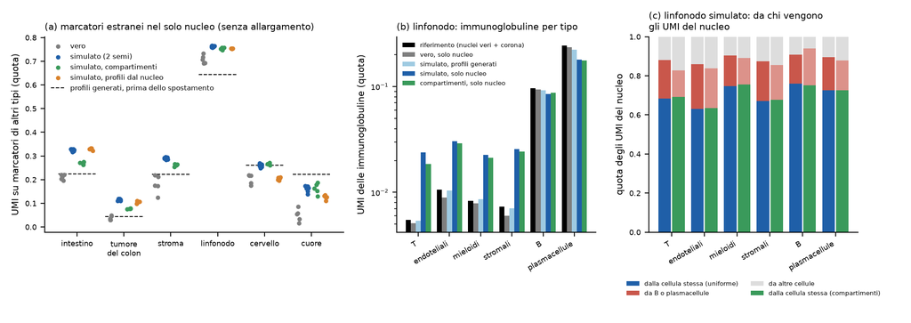

Marcatori estranei nel solo nucleo per tessuto; linfonodo: geni delle immunoglobuline per tipo e origine vera degli UMI nei nuclei simulati. **Cosa guardare**: in intestino, tumore e stroma i punti blu stanno sopra il tratteggio (profili di partenza) e i grigi no; nel linfonodo le barre blu delle cellule T, endoteliali, mieloidi e stromali sono 3-5 volte le grigie.

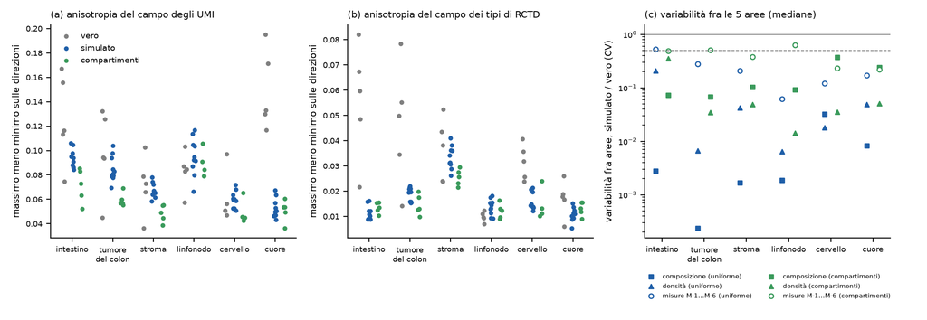

Calcolate dopo la dichiarazione (`4d331b4`). Tabelle in `results/F3.1/F3.1_PH4*`, `F3.1_PH5_*`, `F3.1_PH6_*`, `F3.1_PH7.log`; figure 5 e 6 del report. Gli esiti di F3.1 non cambiano. Dove un’analisi è nata dopo aver visto un risultato lo si scrive (**non pre-registrata**).

**PH-4, linfonodo: non spiegato secondo il criterio; meccanismo trovato dopo** (`tools/F3.1_PH4_lymph.py`, `F3.1_PH4b_blocks.py`, `F3.1_PH4c_ig.py`). - Domanda 1, profili. Con il classificatore multinomiale contro il riferimento di F3.1, i profili veri generati dei B simulati, ridotti alla profondità dei nuclei B veri, sono chiamati plasmacellule nello 0.099 dei casi, i nuclei B veri con la corona nello 0.117: i profili generati **non** assomigliano alle plasmacellule più del vero. Due sottotipi B di R6 sono quasi plasmacellule (202: 354 su 376; 147: 582 su 1 283), sui due lati. - Domanda 2, dopo lo spostamento. **Deviazione dalla dichiarazione**: la classificazione è stata fatta sui soli quadratini del nucleo (prima dell’allargamento di bin2cell), non sulle cellule allargate; il nucleo è la parte più pulita e la domanda (prima o dopo lo spostamento) resta la stessa. B chiamati plasmacellule: vero 0.126, simulato 0.093, compartimenti 0.097, nessun eccesso. Ma le cellule T simulate sono chiamate B nello 0.236 dei casi (vero 0.044; compartimenti 0.171), endoteliali, mieloidi, stromali nello 0.185-0.208 (vero 0.017-0.048). - Blocchi di 8 µm (RCTD), primo tipo = plasmacellule, per tipo del nucleo che domina il blocco: B vero 0.286, simulato 0.323, compartimenti 0.309; T 0.018 / 0.259 / 0.182; endoteliali 0.040 / 0.335 / 0.309; mieloidi 0.034 / 0.290 / 0.320; stromali 0.029 / 0.284 / 0.315; blocchi senza nucleo tipizzato 0.128 / 0.297 / 0.273. Blocchi simulati dominati da B con purezza vera ≥ 0.9: 0.306. Scomposizione dell’eccesso (0.302 contro 0.130 = 0.172): 0.047 dalla composizione dei blocchi (più blocchi B nel simulato, 0.32 contro 0.20), 0.139 dal tasso per tipo, di cui 0.127 dai blocchi non B. - Domanda 3, composizione. Simulato: la stessa nelle 5 aree (B 0.495, T 0.417); vero: B 0.639, 0.581 nei follicoli f1, f2 e 0.331, 0.493, 0.416 nella paracorteccia p1-p3 (T 0.252, 0.341; 0.581, 0.422, 0.500). - Esito secondo il criterio: la confusione non è nei profili e compare dopo lo spostamento, ma i compartimenti ne spiegano solo il 18 % ((0.302 − 0.271) / 0.172): **non spiegato**. - Meccanismo (non pre-registrato, `F3.1_PH4c_ig.py`). Quota degli UMI sui geni delle immunoglobuline (IGKC, JCHAIN, IGHA1, IGHA2, IGHE, IGHG1, IGHG3, IGHD, IGHM, IGLC1, IGLC7) nei soli quadratini del nucleo delle cellule T: riferimento 0.0055, vero 0.0051, profili generati 0.0054, simulato 0.0238, compartimenti 0.0185; endoteliali 0.0106 / 0.0089 / 0.0104 / 0.0303 / 0.0291; stromali 0.0073 / 0.0060 / 0.0071 / 0.0257 / 0.0243. Verità del simulato (`origin.parquet`): degli UMI nei quadratini del nucleo delle T solo 0.684 vengono dalla cellula stessa e 0.196 da B o plasmacellule (compartimenti 0.693 e 0.136); per le altre cellule 0.63-0.76 dalla cellula stessa. Il conto torna: 0.196 × circa 0.10 + 0.684 × 0.0054 ≈ 0.023. Nel vero la quota di immunoglobuline nei nuclei T (0.0051, quanto i nuclei T con la corona) dà un tetto: al più circa 5 % dei loro UMI può venire da B o plasmacellule. **Nel simulato i trascritti delle cellule vicine che finiscono nei nuclei sono circa quattro volte troppi**, e nei blocchi non B il segnale di B e plasmacellule li fa chiamare così.

**Seguito su tutti i tessuti (descrittivo, non pre-registrato; `tools/F3.1_PH4d_spill.py`)**. Marcatori estranei nei soli quadratini del nucleo (vero / simulato / compartimenti / profili dal solo nucleo; tratteggio: profili generati prima dello spostamento):

| tessuto | vero | simulato | compartimenti | profili dal nucleo | profili generati | purezza vera del nucleo (simulato) |
| --- | --- | --- | --- | --- | --- | --- |
| A1 intestino | 0.210 | 0.324 | 0.269 | 0.329 | 0.224 | 0.599 |
| A2 tumore del colon | 0.038 | 0.115 | 0.077 | 0.103 | 0.044 | 0.836 |
| A3 stroma | 0.181 | 0.291 | 0.261 | – | 0.222 | 0.900 |
| A4 linfonodo | 0.708 | 0.762 | 0.754 | 0.754 | 0.645 | 0.727 |
| A5 cervello | 0.203 | 0.261 | 0.266 | 0.204 | 0.261 | 0.898 |
| A6 cuore | 0.050 | 0.163 | 0.162 | 0.125 | 0.222 | 0.901 |

Lettura: in A1-A3 i nuclei veri sono puliti quanto i profili generati, che vengono da nuclei veri con la corona; il simulato aggiunge 0.07-0.11 spostando trascritti delle cellule vicine nei nuclei. L’eccesso resta con i profili dal solo nucleo (A1 0.329, A2 0.103, A4 0.754): non è il doppio conteggio della contaminazione (come già CP-3), è dove il simulatore mette e sposta i trascritti. I compartimenti ne tolgono circa metà in A1 e A2, meno in A3 e A4; in A1 e A4 la mescolanza dei vicini dei compartimenti è già quella vera (PH-3: 0.23 contro 0.22, 0.37 contro 0.36) e l’eccesso resta (0.06 e 0.05). Nel cervello l’eccesso è nei profili (dal solo nucleo 0.204 = vero), nel cuore nei profili generati, più sporchi dei nuclei veri. Candidati, da verificare e non accertati: i parametri dello spostamento di `place_and_move_transcripts()` (gaussiana larga σ_e 4.5-6.2 µm per asse con probabilità exp(−d/D), coda di peso w 0.04-0.11 e scala ℓ 25-42 µm), calibrati in S2.0 su profili di UMI che non distinguono il tipo, e il rapporto nucleo/citoplasma r. → BL-265.

**PH-5, cuore: spiegato per il campo degli UMI, non per il campo dei tipi** (`tools/F3.1_PH5_aniso.py`).

| tessuto | campo dei tipi: vero − simulato | campo degli UMI: vero − simulato |
| --- | --- | --- |
| A1 | 0.0444 ± 0.0102 (oltre 2 ES) | 0.0321 ± 0.0167 |
| A2 | 0.0278 ± 0.0108 (oltre 2 ES) | 0.0132 ± 0.0159 |
| A3 | 0.0030 ± 0.0059 | 0.0040 ± 0.0108 |
| A4 | −0.0038 ± 0.0015 | −0.0118 ± 0.0088 |
| A5 | 0.0151 ± 0.0034 (oltre 2 ES) | 0.0006 ± 0.0098 |
| A6 cuore | 0.0062 ± 0.0034 | **0.0967 ± 0.0151 (oltre 2 ES)** |

Il campo degli UMI per blocco (correlazione direzionale, come in S2.5) vede il cuore (vero 0.149 ± 0.015, simulato 0.053 ± 0.003) e negli altri tessuti la differenza è minore e entro 2 ES: criterio soddisfatto, è la misura da usare per il controllo negativo del cuore. Il campo dei tipi di RCTD non lo vede (i cardiomiociti dominano i due lati); vede invece più orientamento nel vero in intestino, tumore e cervello (strutture orientate: villi e cripte, ghiandole, strati), un altro aspetto della disposizione dei tipi. In A4 il simulato è più anisotropo del vero (−0.0038 ± 0.0015, 2.5 ES: lo script conta solo il verso vero > simulato).

**PH-6, variabilità fra aree: spiegato** (`tools/F3.1_PH6_variability.py`). Rapporto simulato / vero dei coefficienti di variazione fra le 5 aree (mediana sulle quantità di base; densità; mediana su M-1…M-6), semina uniforme: A1 0.0038, 0.21, 0.53; A2 0.0035, 0.0067, 0.28; A3 0.0046, 0.043, 0.21; A4 0.0029, 0.0065, 0.061; A5 0.033, 0.018, 0.12; A6 0.013, 0.049, 0.17. CV della densità, vero contro simulato: A1 0.019 / 0.004, A2 0.095 / 0.001, A3 0.167 / 0.007, A4 0.117 / 0.001, A5 0.374 / 0.007, A6 0.209 / 0.010. Le quantità di base (mediana) variano fra aree da 30 a 350 volte meno del vero in tutti i tessuti (la densità da 5 a 150 volte, la composizione, mediana sui tipi, da 30 a circa 4 000 volte: rapporti 0.0028, 0.00024, 0.0017, 0.0019, 0.033, 0.0083), e le misure dei metodi meno del vero negli stessi tessuti: criterio soddisfatto. Causa: il preset ha una composizione e una densità per tessuto e le aree differiscono solo per la forma delle regioni. Con i compartimenti la composizione varia di più (rapporto 0.07-0.38) ma resta sotto il vero.

**PH-7, geometria: spiegato** (`tools/F3.1_PH7_geom.R`, `F3.1_PH7b_diag.R`). L’errore si riproduce (A5_r3, Q6). Geometria 168: poligono valido, 5 494.3 µm², 253 vertici, 4 anelli (3 buchi), spigolo minimo 0.489 µm; **il buco 1 tocca il bordo esterno in un punto** (permesso dalle regole dei poligoni); la triangolazione vincolata di GEOS 3.11.1 si ferma con «Unable to find a convex corner». Diverso da BL-241 (spigoli cortissimi, risolto dalla semplificazione). Non funzionano, perché lasciano il contatto: make_valid, buffer 0, set_precision 1e-6…1e-2, semplificazione 1e-3…1e-1. Funzionano (prove nate dopo il fallimento delle quattro dichiarate): erosione di 1e-6 µm (area −1.1e-7 relativo) e taglio a griglia di 50 o 20 µm (area esatta, scarto < 1e-15). Correzione candidata: erosione di 1e-6 µm come ultimo ripiego dopo la semplificazione. A5_r3 con la correzione: simulazione completa (9 311 944 UMI, 1 geometria corretta); controllo A5_r1 (Q6): conteggi a 2 µm identici con e senza la correzione (ripiego mai usato; la riga del log dice «8 um» per un’etichetta rimasta dalla prima versione dello script, ma confronta i conteggi a 2 µm, corretta poi nello script). La correzione va nel pacchetto nello step della prova (BL-259).

**Che cosa cambia** 1. Un secondo limite che cambia il comportamento dei metodi: troppi trascritti delle cellule vicine nei nuclei (intestino, tumore, stroma, linfonodo; BL-265). Contribuisce a M-3 e, nel linfonodo, a M-5 e alla composizione di RCTD. La disposizione dei tipi resta il primo limite (DEC-087): i compartimenti tolgono circa metà dell’eccesso dove agiscono; il resto è nello spostamento dei trascritti. 2. La prova dei compartimenti (step successivo) misura anche i marcatori estranei nel solo nucleo e, nel linfonodo, le immunoglobuline nei nuclei T, per separare i due limiti. 3. Controllo negativo del cuore nelle prove dei metodi: anisotropia del campo degli UMI (BL-263). 4. Variabilità fra aree: causa nota (un’unica composizione e densità per tessuto); come produrla è da decidere (BL-262).

# Correzioni

1. **Seme di RCTD** (G-3): vedi sopra. Effetto sugli intervalli del vero già approvati: M-1…M-3 identici; M-4…M-6 spostati al più di 0.0045 (linfonodo, M-6), meno di un decimo della semi-ampiezza, tranne M-4 in intestino e linfonodo dove vale comunque il margine minimo di DEC-086; cuore identico. Intervalli senza seme conservati in `results/F3.1/F3.1_intervals_unseeded.csv`; nessun esito cambia usando quelli (verifica del revisore statistico).
2. **Soglia di RCTD nel cuore** (E-8, prima del simulato).
3. **Batteria G-1**: errore di scrittura nel codice delle prove (definizione del livello del caso commentata per metà), corretto; nessuna asserzione cambiata.

# Revisione avversariale

- **Misure** (sotto-agente con codice proprio, `/mnt/micron/geo_spatialtrans/F3.1/review/misure/`): M-1…M-6 e purezza vera su 12 aree (un’area per tessuto per lato), rifacendo anche l’allargamento di bin2cell: 78 su 78 entro 1e-9 (massimo 9.9e-16); 200 quadratini di un’area vera identici alla matrice grezza di Space Ranger. Tre note di definizione, nessuna discrepanza: (1) M-2 e M-3 sommano anche i quadratini dell’allargamento fuori dal tessuto (sui due lati; limitandoli al tessuto M-2 cambierebbe dello 0.3-2.9 %, M-3 dello 0.01-1.3 %); (2) nel linfonodo 14 marcatori sono nelle liste di due tipi e si contano per lista (contandoli una volta M-3 cambierebbe del 3-4 % sui due lati); (3) il numero di blocchi passati a RCTD comprende gli scartati (descrittivo). Nessuna delle tre sposta un esito: gli scarti relativi delle smentite di M-3 vanno dal 14 % (linfonodo) al 235 % (tumore del colon), e nel linfonodo l’effetto dei marcatori doppi (3-4 %, sui due lati nello stesso verso) resta più piccolo dello scarto.
- **Statistiche** (sotto-agente con codice proprio, `/mnt/micron/geo_spatialtrans/F3.1/review/stat/`): 1 121 quantità (intervalli, esiti, CP-1, CP-3, R-1, riponderazione di PH-1, ricostruzione dei livelli di mescolanza dai dati per cellula): 1 119 tornano. Le 2 diverse: M-3 nello stroma e M-5 nel cervello risultano smentite, invece che indeterminate, se si ricampiona con un altro seme anche l’intervallo del vero; con l’intervallo del vero fissato (come pre-registrato) o con l’enumerazione esatta delle 5⁵ combinazioni tornano gli esiti registrati, 36 su 36. Chiuso come spiegato: sono **due esiti fragili**, a cavallo del limite. Con quegli esiti la regola R-1 avrebbe 9 non attribuiti invece di 7; il limite da sistemare per primo non cambia.

# Deviazioni dichiarate

1. **G-2, controllo (1)**: nella bozza «UMI assegnati + non assegnati = totale» era una tautologia; sostituito, prima di eseguirlo, con il ricalcolo dai file della quota di UMI nei nuclei e degli UMI in tessuto (errore di pre-registrazione scritto come tale).
2. **G-3** passato solo dopo la correzione del seme di RCTD.
3. **Previsioni senza il seme di RCTD**: i valori degli intervalli presentati a Luca sono quelli calcolati senza seme; gli esiti sono giudicati con quelli ricalcolati con il seme (stessa regola, scarti sotto un decimo della semi-ampiezza; nessun esito cambia con i primi).
4. **CP-3 senza lo stroma**: nello stroma del tumore i profili vengono dall’atlante, quindi il braccio con i profili dal nucleo non esiste lì (dichiarato prima del calcolo). Di conseguenza le simulazioni della fase B sono 85 (60 del pannello + 25 con i profili dal nucleo), non le 90 scritte nella richiesta di ok a Luca del 2026-11-12 (30 × 2 + 30): errore di conto in quella richiesta, segnalato dalla revisione.

# Cosa è girato

```bash
cd ~/2025.geo_spatialtrans && git checkout f3-methods
bash tools/F3.1_md5.sh before
.venv/bin/python tools/F3.1_reference.py /mnt/micron/geo_spatialtrans/F3.1/main/ref 20261113 A1 A2 A3 A4 A5 A6
.venv/bin/python tools/F3.1_export_real.py /mnt/micron/geo_spatialtrans/F3.1/main/real <aree>   # poi tools/F3.1_b2c.py (label, label_dimg, label_shift) e tools/F3.1_rctd.R
.venv/bin/python tools/F3.1_intervals.py /mnt/micron/geo_spatialtrans/F3.1/main /mnt/micron/geo_spatialtrans/F3.1/explore/explore_measures_v3.csv results/F3.1
.venv/bin/python tools/F3.1_profiles_nuc.py /mnt/micron/geo_spatialtrans/F3.1/profiles_nuc A1 A2 A4 A5 A6
bash tools/F3.1_run_B.sh 6 && bash tools/F3.1_run_PH3.sh 5
.venv/bin/python tools/F3.1_analysis.py /mnt/micron/geo_spatialtrans/F3.1/main results/F3.1
.venv/bin/python tools/F3.1_PH1_mixing.py /mnt/micron/geo_spatialtrans/F3.1/main results/F3.1/F3.1_PH1_mixing.csv
.venv/bin/python tools/F3.1_PH3_analysis.py /mnt/micron/geo_spatialtrans/F3.1/main results/F3.1
.venv-b2c/bin/python tools/F3.1_test.py /mnt/micron/geo_spatialtrans/F3.1/main      # G-1
.venv-b2c/bin/python tools/F3.1_check.py /mnt/micron/geo_spatialtrans/F3.1/main     # G-2
bash tools/F3.1_repro.sh                                                             # G-3
bash tools/F3.1_md5.sh after                                                         # G-4
.venv/bin/python tools/F3.1_figures.py results/F3.1 reports/F3.1_parts && .venv/bin/python tools/F3.1_report_parts.py && quarto render reports/F3.1.qmd
.venv/bin/python tools/F3.1_PH4_lymph.py /mnt/micron/geo_spatialtrans/F3.1/main results/F3.1        # indagini PH-4...PH-7 (2026-11-18)
.venv/bin/python tools/F3.1_PH4b_blocks.py /mnt/micron/geo_spatialtrans/F3.1/main results/F3.1
.venv/bin/python tools/F3.1_PH4c_ig.py /mnt/micron/geo_spatialtrans/F3.1/main results/F3.1
.venv/bin/python tools/F3.1_PH4d_spill.py /mnt/micron/geo_spatialtrans/F3.1/main results/F3.1
.venv/bin/python tools/F3.1_PH5_aniso.py /mnt/micron/geo_spatialtrans/F3.1/main results/F3.1
.venv/bin/python tools/F3.1_PH6_variability.py /mnt/micron/geo_spatialtrans/F3.1/main results/F3.1
Rscript --vanilla tools/F3.1_PH7_geom.R /mnt/micron/geo_spatialtrans/F3.1/PH7 && Rscript --vanilla tools/F3.1_PH7b_diag.R /mnt/micron/geo_spatialtrans/F3.1/PH7
.venv/bin/python tools/F3.1_figures_PH.py results/F3.1 reports/F3.1_parts
```

Semi: pannello base 20261114 (k = 0, 1; tabella Mersenne-Twister sulle 30 aree ordinate), esplorazione 20261112, riferimento 20261113, intervalli del vero 20261115, intervalli del simulato 20261117, PH-3 20261119, RCTD 20261118, prove 20261116, PH-4 (riduzione dei profili) 20261120. Uscite in `/mnt/micron/geo_spatialtrans/F3.1/` (25G, non nel repository).

# Appendice

## Perimetro

Deciso dall’agente con la delega di Luca su ordine e perimetro delle sessioni dopo S2.5 (DEC-071, punto 2); dettagli e motivazioni in F3.1: perimetro, metodi, riferimento e misure della prima prova dei metodi di analisi (DEC-085).

1. **Due metodi**, i più usati su Visium HD, ciascuno con i parametri predefiniti:
   - **assegnazione dei quadratini di 2 µm alle cellule**: bin2cell 0.3.5[^1], flusso standard (correzione delle strisce `destripe()`, poi `expand_labels()`: i nuclei si allargano fino a 2 quadratini, cioè 4 µm; i pareggi si decidono con la somiglianza di espressione). I nuclei sono dati al metodo: sul vero quelli della maschera adottata in R6 (Cellpose sulle immagini a colori; consenso di Cellpose e StarDist nel linfonodo e nel cuore), sul simulato il nucleo vero (la cellula il cui nucleo copre almeno metà del quadratino). La segmentazione dall’immagine resta fuori: il simulato non ha un’immagine.
   - **deconvoluzione dei blocchi di 8 µm**: RCTD in modalità doppietto[^2] (spacexr 2.2.1, commit `ccc4344`), soglia di 20 UMI per blocco e per cellula del riferimento, il resto ai valori predefiniti.
2. **Riferimento a cellula singola uguale per i due lati**: i nuclei veri con la corona di 8 µm delle 5 aree del tessuto (R6), con il tipo delle etichette adottate di R6 portato al vocabolario dei preset come in S2.2 (l’epitelio normale e quello tumorale diventano un solo epitelio); al più 3 000 cellule per tipo, tipi con almeno 25 cellule. È la stessa sorgente da cui S2.2 ha costruito i profili del simulatore: sul simulato il riferimento è quindi quasi un oracolo, sul vero è stimato sulle stesse aree. Lo si dichiara: le misure confrontano il comportamento, non l’accuratezza assoluta.
3. **Aree**: le 30 aree dello Step 1 (5 per tessuto; nel linfonodo 2 follicoli e 3 aree paracorticali), quadratini «in tessuto» con la definizione di S2.5 (centro nelle regioni dello Step 1 e a più di 25 µm dal bordo). Sul simulato: livelli cellulari U6 di S1.6, `simulate_visium_hd_pieces()` di `dev` con `frame_open = TRUE` e tutti gli strati accesi.
4. **Unità indipendente**: l’area. Intervallo del vero con la correzione per poche aree di R7 (DEC-060, DEC-061).
5. **Fuori perimetro**: segmentazione dall’immagine, altri metodi (ENACT, cell2location, Proseg), aree di cattura intere, l’ottimizzazione di tempo e memoria.

## Metodi e misure

Codice: `tools/F3.1_sim.R`, `tools/F3.1_export_sim.R`, `tools/F3.1_reg_sim.py`, `tools/F3.1_export_real.py`, `tools/F3.1_reference.py`, `tools/F3.1_b2c.py`, `tools/F3.1_rctd.R`. Ambiente di bin2cell: `.venv-b2c` (bin2cell 0.3.5, scanpy 1.12.5). Stesse funzioni sui due lati, a partire dallo stesso formato (matrice per quadratino, quadratini con nucleo e in tessuto, nuclei con tipo).

Misure con previsione (per area; valore del tessuto = media delle 5 aree, sul simulato prima la media dei 2 semi):

| id | misura | definizione |
| --- | --- | --- |
| M-1 | UMI assegnati | quota degli UMI dei quadratini in tessuto che finiscono in una cellula dopo l’allargamento |
| M-2 | UMI per cellula | media degli UMI per cellula dopo l’allargamento (cellule con almeno metà del nucleo in tessuto) |
| M-3 | marcatori estranei | per cellula con tipo e almeno 5 UMI sui marcatori: quota degli UMI sui 50 marcatori degli altri tipi (marcatori dal riferimento); media sulle cellule |
| M-4 | singoletti | quota dei blocchi di 8 µm non scartati che RCTD chiama singoletto |
| M-5 | concordanza con il nucleo | quota dei blocchi (non scartati, con un nucleo tipizzato che copre almeno 4 dei 16 quadratini) in cui il primo tipo di RCTD è il tipo del nucleo |
| M-6 | coerenza spaziale | quota delle coppie di blocchi adiacenti (non scartati) con lo stesso primo tipo |

Misure senza previsione (descrittive o esplicative): numero di cellule per area; blocchi sotto 20 UMI e scartati; M-3 sui profili veri generati (solo simulato); M-1…M-3 con la registrazione corretta dello scarto di R5 (solo vero); verità del simulato: purezza (quota degli UMI assegnati a una cellula che vengono da lei), recupero (quota degli UMI catturati di una cellula finiti nella sua cellula), quota da cellule di altro tipo, accuratezza del primo tipo di RCTD contro il tipo che domina gli UMI del blocco.

## Esplorazioni dichiarate

Un’area per tessuto (A1_r1, A2_r1, A3_r1, A4_p1, A5_r1, A6_r1), simulato con un seme (base 20261112, k = 0), riferimento con il seme 20261113. Cartella `/mnt/micron/geo_spatialtrans/F3.1/explore/`, tabella `explore_measures_v3.csv`. Servono a scrivere le previsioni; non entrano negli esiti.

- **E-1, correzioni della catena trovate in esplorazione** (nessuna tocca il simulatore): (a) le aree del linfonodo si chiamano f1, f2, p1, p2, p3, non r1-r5; (b) il simulato usa gli identificativi Ensembl, il vero i nomi dei geni, che nei pannelli di topo e del cuore non sono unici: tutta la catena ora usa gli identificativi; (c) il simulato del tumore e dello stroma usa un solo epitelio, R6 due: il riferimento e i nuclei veri ora usano il vocabolario dei preset (tabella di S2.2); (d) la matrice filtrata di Space Ranger lascia a zero 1 700 quadratini in tessuto nell’intestino e 2 027 nel tumore: ora si usa la matrice grezza ristretta al pannello, come S2.5. Con (d) l’UMI medio per quadratino in tessuto coincide con S2.5 in tutte le 6 aree (27.244, 51.844, 19.042, 9.48, 43.733, 4.794) e il numero di quadratini in tessuto pure.
- **E-2, quota di UMI dei marcatori di altri tipi nelle cellule di bin2cell** (simulato contro vero): intestino 0.36 contro 0.23; tumore 0.16 contro 0.06; stroma 0.34 contro 0.21; linfonodo 0.76 contro 0.65; cervello 0.30 contro 0.24; cuore 0.20 contro 0.16. Sempre più alta nel simulato.
- **E-3, la stessa quota sui profili veri generati per le cellule simulate** (prima dello spostamento): 0.226, 0.045, 0.227, 0.645, 0.254, 0.225; quasi uguale al vero in cinque tessuti su sei (cuore più alto). Ipotesi: i profili del simulatore, presi dai nuclei veri con la corona, contengono già i trascritti dei vicini, e lo spostamento del simulatore ne aggiunge altri (contaminazione contata due volte). Va messa alla prova (CP-3).
- **E-4, RCTD**: concordanza del tipo con il nucleo del blocco, simulato contro vero: 0.84/0.88, 0.92/0.99, 0.80/0.90, 0.42/0.65, 0.94/0.89, 0.83/0.83; stesso tipo fra blocchi vicini: 0.83/0.91, 0.77/0.92, 0.65/0.91, 0.34/0.46, 0.82/0.79, 0.72/0.82. Nel linfonodo simulato RCTD chiama plasmacellule molti blocchi di linfociti B (2 669 su 8 063).
- **E-5, quota di UMI assegnati alle cellule** (nuclei allargati): 0.75/0.67, 0.82/0.78, 0.42/0.60, 1.00/0.99, 0.35/0.46, 0.16/0.14; segue il numero di cellule dell’area (simulato contro vero: 9 138/7 993, 6 078/6 030, 2 788/3 715, 25 398/28 401, 794/1 116, 823/614).
- **E-6, controprova dei nuclei spostati di 20 µm**: la purezza vera delle cellule di bin2cell scende a 0.00-0.08 in tutti i tessuti; la quota di marcatori estranei sale e la concordanza di RCTD con il nucleo scende su entrambi i lati, debolmente nel linfonodo (marcatori) e nel cuore vero (concordanza 0.83, poi 0.76).
- **E-8, soglia di RCTD nel cuore** (trovata nella fase A, prima di ogni calcolo sul simulato): nelle aree r2 e r3 del cuore vero nessun blocco supera 300 UMI e RCTD si ferma («N_fit of 0» nella stima del rumore, parametro `UMI_min_sigma`); nelle altre tre aree del cuore lo superano 2-10 blocchi, negli altri tessuti da 169 a 11 486. Regola tecnica, uguale per i due lati: `UMI_min_sigma` = il minore fra 300 e l’UMI del centesimo blocco più ricco dell’area. Cambia solo dove meno di 100 blocchi superano 300 (in questi dati: le cinque aree vere del cuore, 107-216 UMI, e il cuore simulato dell’esplorazione); le aree vere del cuore sono state rifatte. Inoltre il JSON di RCTD ora è scritto a precisione piena (era a 6 cifre: il ricalcolo di G-1 tornava solo alla sesta cifra) e le misure si possono ricalcolare dalla tabella per blocco senza rifare RCTD.
- **E-7, tempi**: simulazione di un’area 130-418 s con 6 processi; bin2cell 1-3 min; RCTD 7-20 min per area (un processo).

## Attese pre-registrate

Commit dei cancelli: `fc79131` («F3.1: perimetro, esplorazioni, misure, cancelli»). Ok di Luca sulle previsioni, sulle soglie (intervalli corretti del vero), sulla regola R-1 e sulle controprove, e sul calcolo (circa 5 ore con 6 processi): 2026-11-12, «Ok, come proposte (Consigliato)». Margine minimo per M-4: 2026-11-12, «Margine minimo di un punto percentuale (Consigliato)» (F3.1: margine minimo di un punto percentuale per la quota di singoletti di RCTD (DEC-086)).

### Cancelli (al massimo 5)

[output not shown]

### Regola di decisione dei dati (scritta prima del calcolo)

**R-1, che cosa sistemare per primo** (versione del 2026-11-12, dopo la fase A e prima del simulato; sostituisce la tabella della bozza `fc79131`, che legava ogni misura a un solo limite). Ogni giudizio smentito (misura × tessuto, cuore escluso; solo le misure che passano CP-1 in quel tessuto, per M-3 e M-5) si attribuisce così, nell’ordine:

1. **profili presi dai nuclei con la corona** (contaminazione contata due volte, E-3): se il braccio di CP-3 sposta la misura verso il vero di almeno metà dello scarto (valore del tessuto, simulato principale contro vero). Solo intestino, tumore, linfonodo, cervello (dove i profili vengono dai nuclei).
2. **densità dei preset** (DEC-069, S2.2 punto 4): M-1 e M-2, se lo scarto ha lo stesso segno dello scarto fra cellule simulate e nuclei veri per area, e quel rapporto è fuori da 0.9-1.1.
3. **tipi disposti senza guardare la posizione e semina uniforme** (S2.2 punto 2; limiti della guida d’uso): M-4 e M-6, se lo scarto è per difetto.
4. altrimenti **non attribuito**: diventa un dubbio.

Il limite da sistemare per primo è quello con più giudizi attribuiti; a pari numero, quello con lo scarto medio più grande in unità della semi-ampiezza dell’intervallo del vero. Il risultato si registra come decisione tecnica.

### Previsioni

Unità indipendente: l’area (5 per tessuto e per lato). Intervallo di rilevanza = intervallo corretto del valore vero del tessuto (fonte (2) del protocollo: variabilità fra aree vere; costruzione di DEC-060 e DEC-061, B = 2 000, seme 20261115; tabella `results/F3.1/F3.1_intervals.csv`). Intervallo del simulato: stessa costruzione con il fattore per poche unità del lato simulato (1.632). Esito per tessuto: confermata, smentita, indeterminata.

**Valore atteso**: valore vero del tessuto più lo scarto simulato meno vero visto sull’area dell’esplorazione; **2 errori standard tipici del simulato**: semi-ampiezza del bootstrap del vero per 1.632, cioè supponendo che il simulato vari fra aree quanto il vero. La semi-ampiezza dell’intervallo del vero è 1.0-2.4 volte questi 2 errori standard: una conferma è possibile solo se il simulato varia fra aree meno del vero (in S2.5 accadeva); le smentite con scarti grandi restano nette.

**Margine minimo per M-4** (deciso da Luca il 2026-11-12, DEC-086): dove nel vero RCTD chiama singoletto quasi ogni blocco (intestino, linfonodo, cervello, cuore) l’intervallo del vero è largo meno di un millesimo; proposta: intervallo di rilevanza almeno [vero − 0.01, vero + 0.01] (un punto percentuale di blocchi chiamati doppietto). Con il margine, l’esito atteso di M-4 diventa: smentita nell’intestino, nel tumore e nello stroma; confermata o indeterminata nel linfonodo, nel cervello e nel cuore.

| misura | tessuto | vero | intervallo di rilevanza | atteso simulato ± 2 ES | esito atteso (senza margine minimo) |
| --- | --- | --- | --- | --- | --- |
| M-1 | A1 | 0.676 | 0.667-0.684 | 0.753 ± 0.007 | smentita |
| M-1 | A2 | 0.744 | 0.717-0.776 | 0.784 ± 0.029 | indeterminata |
| M-1 | A3 | 0.586 | 0.389-0.713 | 0.400 ± 0.083 | indeterminata |
| M-1 | A4 | 0.984 | 0.969-0.999 | 0.990 ± 0.010 | indeterminata |
| M-1 | A5 | 0.387 | 0.326-0.453 | 0.281 ± 0.057 | indeterminata |
| M-1 | A6 | 0.177 | 0.139-0.211 | 0.196 ± 0.036 | indeterminata |
| M-2 | A1 | 470 | 414-526 | 504 ± 49 | indeterminata |
| M-2 | A2 | 1136 | 923-1352 | 1084 ± 210 | indeterminata |
| M-2 | A3 | 669 | 403-837 | 631 ± 126 | confermata |
| M-2 | A4 | 102 | 56-149 | 130 ± 25 | indeterminata |
| M-2 | A5 | 4514 | 1534-6564 | 4782 ± 1062 | confermata |
| M-2 | A6 | 150 | 80-226 | 64 ± 73 | indeterminata |
| M-3 | A1 | 0.241 | 0.226-0.255 | 0.374 ± 0.013 | smentita |
| M-3 | A2 | 0.045 | 0.035-0.057 | 0.144 ± 0.011 | smentita |
| M-3 | A3 | 0.222 | 0.118-0.334 | 0.346 ± 0.063 | indeterminata |
| M-3 | A4 | 0.672 | 0.630-0.708 | 0.790 ± 0.021 | smentita |
| M-3 | A5 | 0.232 | 0.179-0.285 | 0.294 ± 0.022 | indeterminata |
| M-3 | A6 | 0.164 | 0.136-0.192 | 0.199 ± 0.028 | indeterminata |
| M-4 | A1 | 1.000 | 1.000-1.000 | 0.973 ± 0.000 | smentita |
| M-4 | A2 | 0.954 | 0.940-0.968 | 0.816 ± 0.014 | smentita |
| M-4 | A3 | 0.985 | 0.971-0.999 | 0.840 ± 0.007 | smentita |
| M-4 | A4 | 0.999 | 0.998-1.000 | 0.992 ± 0.001 | smentita |
| M-4 | A5 | 1.000 | 0.999-1.000 | 1.000 ± 0.000 | smentita |
| M-4 | A6 | 1.000 | 1.000-1.000 | 1.000 ± 0.000 | confermata |
| M-5 | A1 | 0.864 | 0.843-0.882 | 0.825 ± 0.017 | smentita |
| M-5 | A2 | 0.990 | 0.987-0.993 | 0.922 ± 0.003 | smentita |
| M-5 | A3 | 0.890 | 0.835-0.941 | 0.788 ± 0.027 | smentita |
| M-5 | A4 | 0.602 | 0.459-0.699 | 0.374 ± 0.076 | smentita |
| M-5 | A5 | 0.904 | 0.874-0.941 | 0.950 ± 0.030 | indeterminata |
| M-5 | A6 | 0.809 | 0.783-0.832 | 0.808 ± 0.025 | indeterminata |
| M-6 | A1 | 0.909 | 0.899-0.919 | 0.825 ± 0.009 | smentita |
| M-6 | A2 | 0.936 | 0.920-0.951 | 0.790 ± 0.015 | smentita |
| M-6 | A3 | 0.886 | 0.846-0.929 | 0.621 ± 0.021 | smentita |
| M-6 | A4 | 0.472 | 0.416-0.520 | 0.354 ± 0.033 | smentita |
| M-6 | A5 | 0.775 | 0.755-0.796 | 0.811 ± 0.019 | indeterminata |
| M-6 | A6 | 0.750 | 0.685-0.816 | 0.649 ± 0.066 | indeterminata |

In sintesi (P-1…P-6 = M-1…M-6, giudicate per tessuto):

- **P-1, UMI assegnati**: smentita per eccesso nell’intestino (più cellule nel preset); indeterminata negli altri.
- **P-2, UMI per cellula**: confermata o indeterminata ovunque (intervalli larghi).
- **P-3, marcatori estranei**: smentita per eccesso nell’intestino, nel tumore e nel linfonodo; indeterminata nello stroma, nel cervello e nel cuore.
- **P-4, singoletti**: smentita per difetto nell’intestino, nel tumore e nello stroma (con il margine minimo).
- **P-5, concordanza con il nucleo**: smentita per difetto nell’intestino, nel tumore, nello stroma e nel linfonodo; indeterminata nel cervello e nel cuore.
- **P-6, coerenza spaziale**: smentita per difetto nell’intestino, nel tumore, nello stroma e nel linfonodo; indeterminata nel cervello; nel cuore indeterminata (vedi CP-4).

### Controprove

- **CP-1, le misure vedono gli errori di assegnazione?** Nuclei spostati di 20 µm in diagonale (bin2cell) e tipo del nucleo preso 24 µm più in là (RCTD), sui due lati: M-3 deve salire e M-5 scendere di più di 2 errori standard in ogni tessuto. Dove non succede, quella misura in quel tessuto non dice nulla sull’assegnazione e il suo esito non entra nella regola R-1. **Lato vero, fase A: passa in tutti e sei i tessuti per M-3 e M-5** (`results/F3.1/F3.1_CP1_real.csv`; la più debole: M-5 nel cuore, 0.093 ± 0.037).
- **CP-2, le misure senza verità seguono la verità?** Sulle 60 esecuzioni simulate: correlazione fra aree della quota di marcatori estranei (M-3) con la quota vera di UMI da cellule di altro tipo, e della concordanza con il nucleo (M-5) con l’accuratezza vera di RCTD; attesa positiva in almeno 4 tessuti su 6.
- **CP-3, la contaminazione contata due volte.** Braccio con i profili presi dal solo nucleo (stessi sottotipi, stessi trascritti per cellula, stesso fattore di profondità; cambia solo la composizione in geni), 30 aree × 1 seme: se l’ipotesi di E-3 è giusta, M-3 scende verso il vero di almeno metà dello scarto in almeno 3 dei 4 tessuti con profili dai nuclei (intestino, tumore, linfonodo, cervello; nello stroma i profili vengono dall’atlante, il cuore è il controllo negativo). Profili: stessi file di S2.2 con le somme per sottotipo ricalcolate sui conteggi del solo nucleo degli stessi nuclei (`tools/F3.1_profiles_nuc.py`); trascritti per cellula, dispersioni e fattore di profondità invariati. L’UMI medio per quadratino si riporta come controllo.
- **CP-4, il cuore come controllo negativo.** Cellule isotrope nel simulato, fibre allungate nel vero: M-6 smentita per difetto nel cuore. Se non lo è, la misura non vede un limite noto. Nota dopo la fase A: l’esplorazione fa attendere un esito indeterminato (0.65 ± 0.07 contro 0.69-0.82), quindi questa controprova può fallire per mancanza di precisione, non solo di sensibilità; lo si dirà.

## Da dove vengono i numeri del riassunto

| frase del riassunto | fonte (tabella o file, riga) | valore letto |
| --- | --- | --- |
| 18 confronti su 36 | results/F3.1/F3.1_verdicts.csv, colonna verdict = smentita | 18 |
| tumore: 15 % contro meno del 5 % (marcatori estranei) | F3.1_verdicts.csv, M-3, A2: sim_est, real_est | 0.1515, 0.0452 |
| tumore: quasi un quadrato su cinque contro uno su venti (miscugli) | F3.1_verdicts.csv, M-4, A2 (1 − singoletti) | 0.1854, 0.0461 |
| stroma: 65 % contro 89 % (stesso tipo fra vicini) | F3.1_verdicts.csv, M-6, A3 | 0.6489, 0.8861 |
| trascritti per cellula tornano in tutti e sei i tessuti | F3.1_verdicts.csv, M-2 | confermata, confermata, confermata, confermata, confermata, confermata |
| intestino: quasi la metà contro un quinto dei vicini di altro tipo | F3.1_PH1_mixing.csv, mix_mean (media per area, poi per tessuto) | 0.472, 0.217 |
| tumore: un terzo contro uno su sedici | F3.1_PH1_mixing.csv, mix_mean | 0.345, 0.061 |
| quasi tutti (intestino) e due terzi (tumore) dei trascritti estranei in più | F3.1_PH1_mixing_reweight.csv, side = sim, fraction_of_gap_explained | 0.945, 0.651 |
| intestino: stroma in un quadrato su dodici contro uno su quattro | F3.1_PH1_mixing_rctd_composition.csv, A1, stromale e muscolo liscio | 0.078, 0.253 |
| stessa quota di cellule stromali, una su cinque | cells.parquet delle 5 aree simulate k = 0; ref_A1.json types_pool | 0.214; 8275/38681 = 0.214 |
| da un terzo a quasi tutta la differenza (miscugli, ordine, accordo) | F3.1_PH3.csv, fraction_closed, M-4…M-6 smentite fuori dal cervello | 0.37-0.95 |
| circa metà sulle cellule sporche (intestino, tumore) | F3.1_PH3.csv, M-3, A1 e A2 | 0.523, 0.595 |
| 5 delle 17 differenze spariscono | F3.1_PH3.csv con F3.1_verdicts.csv: smentite fuori dal cuore e Q6_vs_real diverso da smentita | 5 su 17 |
| con profili dal solo nucleo restano sporche, tranne il cervello | F3.1_CP3.csv, M-3, fraction_closed | A1 -0.06, A2 0.11, A4 0.08, A5 0.65 |
| linfonodo: plasmacellule 30 % contro 13 % | F3.1_PH1_mixing_rctd_composition.csv, A4, plasmacellule | 0.302, 0.130 |
| cuore: nessuna misura vede le cellule allungate | F3.1_verdicts.csv, M-6, A6 | confermata |
| una delle cinque aree del cervello si ferma | /mnt/micron/geo_spatialtrans/F3.1/main/logs_sim_q6.log | ERROR A5_r3 .s27_cdt() |
| simulazione di un’area 2-7 minuti; RCTD 4-20 minuti (mediana 11) | esplorazione E-7 (130-418 s); rctd_sec di F3.1_real_runs.csv, F3.1_sim_runs.csv, F3.1_simnuc_runs.csv | 232-1209 s, mediana 662 s |
| linfonodo: geni degli anticorpi nei nuclei T quasi cinque volte | results/F3.1/F3.1_PH4c_ig_share.csv, linfociti T: sim_nucleus_bins, real_nucleus_bins | 0.0238, 0.0051 |
| un quinto di quello che si raccoglie sopra un nucleo T viene da B o plasmacellule | F3.1_PH4c_origin.csv, sim, linfociti T, B_pl_share | 0.196 |
| nel vero al massimo un ventesimo | F3.1_PH4c_ig_share.csv: 0.0051 / 0.0937 (immunoglobuline nei nuclei T veri / nei nuclei B veri) | 0.054 |
| profili dei linfociti B giusti | F3.1_PH4_lymph_calls.csv: B chiamati plasmacellule, sim_profile_thinned contro real_exp | 0.099, 0.117 |
| plasmacellule 30 % contro 13 %; tre quarti dell’eccesso da quadrati di altre cellule | results/F3.1/F3.1_PH4b_decomposition.csv: excess, rate_nonB | 0.302, 0.130; 0.127/0.172 = 0.74 |
| nuclei veri puliti quanto i profili, simulati no (intestino, tumore, stroma) | F3.1_PH4d_spill.csv, foreign_nuc (real, sim), foreign_profile | A1 0.210/0.324/0.224; A2 0.038/0.115/0.044; A3 0.181/0.291/0.222 |
| anche con i profili dal solo nucleo l’eccesso resta | F3.1_PH4d_spill_simnuc_areas.csv, foreign_nuc | A1 0.329, A2 0.103, A4 0.754 |
| i compartimenti ne tolgono circa metà nell’intestino e nel tumore | F3.1_PH4d_spill.csv, simq6 | A1 0.269 (eccesso da 0.114 a 0.059), A2 0.077 (da 0.077 a 0.039) |
| nell’intestino e nel linfonodo i vicini già mescolati come nel vero | F3.1_PH3.csv / PH-3, mescolanza Q6 contro vero | A1 0.23/0.22, A4 0.37/0.36 |
| la misura dell’orientamento vede il cuore e non gli altri tessuti | F3.1_PH5_aniso_diff.csv, aniso_umi | A6 0.0967 ± 0.0151; altri entro 2 ES |
| composizione da 30 a migliaia di volte, densità da 5 a 150 volte meno | F3.1_PH6_summary.csv, sim: median_cv_ratio_types, cv_ratio_density | 0.00024-0.033; 0.0065-0.21 |
| follicoli e paracorteccia simulati con il 49 % di B, veri dal 33 % al 64 % | F3.1_PH4_composition.csv, linfociti B | 0.495; 0.331-0.639 |
| errore di geometria capito e corretto; area di controllo identica | results/F3.1/F3.1_PH7.log; `tools/F3.1_PH7b_diag.R` | buco 1 tocca il bordo; A5_r3 ok (9 311 944 UMI); A5_r1 identica TRUE |
| nel cervello l’eccesso sta nei profili | F3.1_PH4d_spill.csv e simnuc, A5 | vero 0.203, simulato 0.261, profili dal nucleo 0.204 |

## Footnotes

[^1]: Polański et al. 2024, Bin2cell reconstructs cells from high resolution Visium HD data
[^2]: Cable et al. 2022, Robust decomposition of cell type mixtures in spatial transcriptomics (RCTD)